# Week 04

Data wrangling II

### Data Scientist of the Week

[Mike Dairyko](https://hardin47.github.io/CURV/scholars/dairyko.html)

### Thursday Announcements

- 2 Stats Experience Points due Saturday
- Sign up for project groups on Canvas by class-time on Tuesday
  - choose your own groups of 2
  - who will you work well with?
  - who do you have common (data) interests with? Check out initial Campuswire responses

What’s ahead:

- Weeks 1 - 4, foundational coding techniques
- Weeks 5 - 7, Exam/Start Projects/Ethics
- Weeks 8 - 11, statistical analysis techniques
- Weeks 12 - 15, communicating results / Projects
- Only 4 more labs (after Lab 04), 7 project work sessions

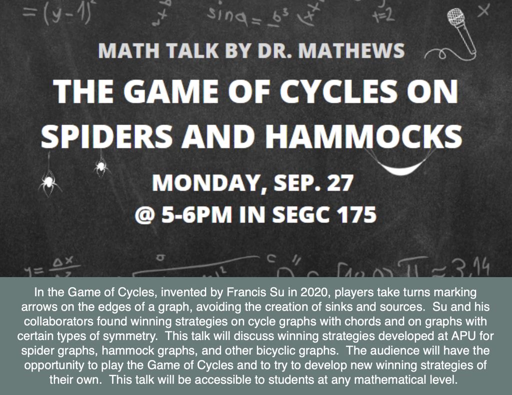

### Announcements

- Lab 03 due now
- First 2 Stats Experience Points due Saturday (remember to post brief reflection on Campuswire)
  - [Informational Interview resource](https://docs.google.com/document/d/17ESP_xm-kXo3gsRrzmbG0XR37yRqnMCT5TiqPli6Pnc/edit?usp=sharing)
  - [Appointment slots](https://calendar.google.com/calendar/selfsched?sstoken=UUdib21reE5QbWlCfGRlZmF1bHR8Y2Q4NzA0ODFhZjhiNjQzYWJlZjU0YzVjNDQ3NzBmNTY) for dinner with me after class
- Exam made available at end of class next Tuesday, due following Tuesday
  - Like a lab, just completed on your own
  - Coding techniques learned in Weeks 1 - 4
  - Open note, open internet

### Tidyverse style guidelines

[Tidyverse style guidelines](https://style.tidyverse.org/pipes.html) for line breaks, white space, etc.

1. Have space before `%>%` and a linebreak after

```r
# Good
iris %>%
  group_by(Species) %>%
  summarize_if(is.numeric, mean) %>%
  ungroup() %>%
  gather(measure, value, -Species) %>%
  arrange(value)

# Bad
iris %>% group_by(Species) %>% summarize_all(mean) %>%
ungroup %>% gather(measure, value, -Species) %>%
arrange(value)
```

2. `ggplot()` layers each go on their own line, space before `+`, all but first layer indented.

```r
# Good
ggplot(aes(x = Sepal.Width, y = Sepal.Length, color = Species)) +
  geom_point() +
  labs(
    x = "Sepal width, in cm",
    y = "Sepal length, in cm",
    title = "Sepal length vs. width of irises"
  )

# Bad
ggplot(aes(x = Sepal.Width, y = Sepal.Length, color = Species))+
  geom_point() + labs(x = "Sepal width, in cm", y = "Sepal length, in cm", title = "Sepal length vs. width of irises")
```

3. If arguments to a function don’t fit on one line, put each argument on its own line

```r
iris %>%
  group_by(Species) %>%
  summarise(
    Sepal.Length = mean(Sepal.Length),
    Sepal.Width = mean(Sepal.Width),
    Species = n_distinct(Species)
  )

iris %>%
  group_by(Species) %>%
  summarise(Sepal.Length = mean(Sepal.Length),
            Sepal.Width = mean(Sepal.Width),
            Species = n_distinct(Species))
```

4. Spaces on each side of all operators (e.g. `+, =, &, <-,`) and after commas

```r
# Good
iris %>%
  mutate(ratio = Sepal.Length/Sepal.Width) %>%
  ggplot(aes(x = Sepal.Width, y = Sepal.Length)) +
  geom_point()

# Bad
iris%>%
  mutate(ratio=Sepal.Length/Sepal.Width) %>%
  ggplot(aes(x=Sepal.Width,y = Sepal.Length)) +
  geom_point()
```

### Questions

*What’s the difference between the various “reflection” questions included on the lab?*

- “Write a brief paragraph summarizing what you found through this analysis, what limitations might exist to the data/analyses, and what additional data you would like to have to explore further questions”
  - More about what you learned from the DATA (e.g. Engineering majors have highest paying careers)
- Reflection prompt “what were the main topics covered in this lab” is more about the techincal coding skills that were covered (e.g. arranging, summarizing data)

*Is there a way to debug code in RStudio? I’m not too familiar with it so whenever I get an error, I just go about the trial-and-error method until it works, but this can be a long and exhausting process.*

- Google your errors :) stackoverflow.com typically has a lot of great help
- use the `?` command with the name of the function to pull up the help documentation. E.g. `?mean` will pull up the documentation for the function `mean()`
- Run one piece of a pipe chain at a time, inspecting the dimensions/output each time

### Application Exercise

- The remainder of class will be spent on AE-04.
- You can access it from GitHub.
- It is due at the end of class today.
- To turn it in, you should upload your .html file to Canvas.